# IMT 573 - Problem Set 3 - Working With Data Part 1

### Instructions

Before beginning this assignment, please ensure you have access to a working instance of Jupyter Notebooks with Python 3.

1. First, replace the “YOUR NAME HERE” text in the next cell with your own full name. Any collaborators must also be listed in this cell.
2. Be sure to include well-documented (e.g. commented) code cells, figures, and clearly written text explanations as necessary. Any figures should be clearly labeled and appropriately referenced within the text. Be sure that each visualization adds value to your written explanation; avoid redundancy – you do no need four different visualizations of the same pattern.
3. Collaboration on problem sets and labs is fun, useful, and encouraged. However, each student must turn in an individual write-up in their own words as well as code/work that is their own. Regardless of whether you work with others, what you turn in must be your own work; this includes code and interpretation of results. The names of all collaborators must be listed on each assignment. Do not copy-and-paste from other students’ responses or code - your code should never be on any other student's screen or machine.
4. All materials and resources that you use (with the exception of lecture slides) must be appropriately referenced within your assignment.
5. Partial credit will be awarded for each question for which a serious attempt at finding an answer has been shown. Students are *strongly* encouraged to attempt each question and document their reasoning process even if they cannot find the correct answer.
6. After completing the assignment, ensure that your code can run from start to finish without issue. Restart the kernal and run all cells to double check.

Name: Ana K. Santiago

Collaborators:

For this assignment, you'll need (at least) the following packages. If the package does not load, be sure it is properly installed.

```python
import pandas as pd
import seaborn as sns
import matplotlib.pyplot as plt
```

In this problem set, we will continue to use data on animals at shelters in the city of [Long Beach, California](https://en.wikipedia.org/wiki/Long_Beach,\_California) that we used in the previous problem set. The data can be found in the `animal_intakes_and_outcomes.csv` file. You can find more information on this data here.

```python
animal_data = pd.read_csv('animal-shelter-intakes-and-outcomes-2.csv')
```

### Problem 1: Describing the animal shelter data

Load the animal sheter data in and ensure you know the variables in the data. Keep the documentation of the dataset nearby.

```python
animal_data.head()
```

|  | Animal ID | Animal Name | Animal Type | Primary Color | Secondary Color | Sex | DOB | Age | Intake Date | Intake Condition | ... | Intake Subtype | Reason for Intake | Outcome Date | Crossing | Jurisdiction | Outcome Type | Outcome Subtype | intake_is_dead | outcome_is_dead | was_outcome_alive |
| --- | --- | --- | --- | --- | --- | --- | --- | --- | --- | --- | --- | --- | --- | --- | --- | --- | --- | --- | --- | --- | --- |
| 0 | A002500 | PENELOPE | DOG | WHITE | NaN | Spayed | 2008-12-09 | 14.0 | 2017-07-02 | NORMAL | ... | POLICE | NaN | 2017-07-03 | 4600 E OCEAN BLVD, LONG BEACH, CA 90803 | LONG BEACH | RETURN TO OWNER | FRE RID HM | Alive on Intake | False | 1 |
| 1 | A226033 | SNOOPY | DOG | WHITE | NaN | Neutered | 2002-02-23 | 21.0 | 2017-10-08 | NORMAL | ... | OTC | NaN | 2017-10-08 | 13200 BLK ACORO PL, CERRITOS, CA 90703 | CERRITOS | RETURN TO OWNER | FRE RID HM | Alive on Intake | False | 1 |
| 2 | A234250 | NINA | DOG | BR BRINDLE | NaN | Spayed | 2008-08-01 | 15.0 | 2018-06-01 | ILL SEVERE | ... | CRUELTY | NaN | 2018-06-07 | 1900 W BURNETT ST, LONG BEACH, CA 90810 | LONG BEACH | EUTHANASIA | ILL SEVERE | Alive on Intake | True | 0 |
| 3 | A238953 | CECE | DOG | BUFF | NaN | Female | 2013-07-17 | 10.0 | 2017-01-03 | NORMAL | ... | FIELD | NaN | 2017-01-03 | 400 E HULLET ST, LONG BEACH, CA 90805 | LONG BEACH | RETURN TO OWNER | FRE RID HM | Alive on Intake | False | 1 |
| 4 | A242600 | BARBY | DOG | BLACK | NaN | Spayed | 2007-10-27 | 15.0 | 2020-11-18 | NORMAL | ... | OTC | NaN | 2020-11-19 | 2000 BLK W COWLES ST, LONG BEACH, CA 90813 | LONG BEACH | RESCUE | LIVELOVE | Alive on Intake | False | 1 |

5 rows × 21 columns

#### (a) Describe and summarize

Answer the following questions to describe and summarize the data:

- How many records are in the data?
- How many unique animals are in the data?
- How many types of animals are included in the data? What types are these?
- Across how many years does the data span? What are the years?
- How many primarily black cats less than 3 years of age were found in Los Alamitos?
- What is the most common primary/secondary color combination in the data (consider only when both colors are listed)?

```python
#using shape method to find number of records
animal_data.shape

#code to count the specific animal types recorded
animal_type_count = animal_data['Animal Type'].value_counts()
#print(animal_type_count)

#code to count the species overall
animal_type_count.shape

#code to find the animal type categories
animal_data['Animal Type'].unique()

#adding a year column
animal_data['Intake Year'] = animal_data['Intake Date'].str.slice(stop = 4)
#print(animal_data.head())

#finding the earliest and most recent years in question
earliest_year = int(animal_data['Intake Year'].min())
recent_year = int(animal_data['Intake Year'].max())

#finding number of years in data
years_in_data = recent_year - earliest_year
#print(years_in_data)

#filtering data to Los Alamitos 'Jurisdiction'
alamitos_data = animal_data.loc[animal_data['Jurisdiction'] == 'LOS ALAMITOS']

#filtering cat data in los alamitos
cat_alamitos_data = alamitos_data.loc[alamitos_data['Animal Type'] == 'CAT']

#filtering for black cats & age at once
young_black_cats_alamitos = cat_alamitos_data.loc[(cat_alamitos_data['Primary Color'] == 'BLACK') & (cat_alamitos_data['Age'] < 3.0)]
young_black_cats_alamitos.head()
len(young_black_cats_alamitos)

#creating copy of DF to store the records with both primary and secondary color values
animal_color_data = animal_data.copy()
#filtering nan values out for secondary colors in overall data
animal_color_data = animal_color_data[animal_color_data['Secondary Color'].notna()]
len(animal_color_data)

#counting times a primary + secondary color combo repeats
animal_color_combos = animal_color_data.groupby(['Primary Color', 'Secondary Color'])
count_combos = animal_color_combos.size().reset_index(name = 'Tally')
common_combo = count_combos.max()
print(common_combo)
```

```
Primary Color      YELLOW
Secondary Color    YELLOW
Tally                4309
dtype: object
```

#### (b) Reflect and question

Comment on the questions (and answers) so far. Were you able to answer all of these questions? Are all questions well defined? Is the data good enough to answer all these?

The data provided sufficient information to answer these questions, and I think I was able to answer all the questions with the information provided. I particularly enjoyed filtering for specific conditions like finding black cats younger than 3 years old in Los Alamitos. I think the questions are well defined though I had a bit of trouble differentiating questions 2 and 3 as they asked for relatively similar information.

### Problem 2: Animal ages

#### (a) Typical ages

What is the typical age of animals in the data?

```python
#removing missing age observations (if any)
print(len(animal_data))
animal_age_data = animal_data[animal_data['Age'].notna()]
print(len(animal_age_data))

#grouping by animal types
animal_groups = animal_age_data.groupby('Animal Type')

#counting the animals in each age group
typical_age_groups = animal_groups['Age'].value_counts()

#finding the value of these groups with the most number of animals per species
print(typical_age_groups.groupby('Animal Type').idxmax())
#finding youngest age
print(typical_age_groups.groupby('Animal Type').idxmin())

#finding atypical values
atypical_ages = animal_data.loc[animal_data['Age'] < 0]
print(atypical_ages)
```

```
39886
34863
Animal Type
AMPHIBIAN      (AMPHIBIAN, 1.0)
BIRD                (BIRD, 6.0)
CAT                  (CAT, 6.0)
DOG                  (DOG, 6.0)
GUINEA PIG    (GUINEA PIG, 1.0)
LIVESTOCK      (LIVESTOCK, 4.0)
OTHER              (OTHER, 1.0)
RABBIT            (RABBIT, 2.0)
REPTILE          (REPTILE, 5.0)
WILD                (WILD, 6.0)
Name: Age, dtype: object
Animal Type
AMPHIBIAN      (AMPHIBIAN, 1.0)
BIRD               (BIRD, 10.0)
CAT                 (CAT, -7.0)
DOG                 (DOG, 26.0)
GUINEA PIG    (GUINEA PIG, 9.0)
LIVESTOCK      (LIVESTOCK, 2.0)
OTHER             (OTHER, 10.0)
RABBIT           (RABBIT, 12.0)
REPTILE         (REPTILE, 15.0)
WILD               (WILD, 16.0)
Name: Age, dtype: object
      Animal ID Animal Name Animal Type Primary Color Secondary Color   Sex  \
30963   A656513           *         CAT         BLACK           WHITE  Male

              DOB  Age Intake Date  Intake Condition  ... Reason for Intake  \
30963  2031-03-30 -7.0  2021-04-21  UNDER AGE/WEIGHT  ...               NaN

      Outcome Date                                Crossing Jurisdiction  \
30963   2021-04-21  7700 E SPRING ST, LONG BEACH, CA 90815   LONG BEACH

      Outcome Type Outcome Subtype   intake_is_dead outcome_is_dead  \
30963       RESCUE        HOUSEOBC  Alive on Intake           False

      was_outcome_alive  Intake Year
30963                 1         2021

[1 rows x 22 columns]
```

While typical ages differ across different species of animals, it looks like the most common age for birds, cats, dogs, and wild animals is 6.0 years old. Reptiles' most common age is 5, while livestock's is 4. The most common age for rabbits is 2 years old, while amphibians, guinea pigs, and 'other' animals is 1 year old.

#### (b) Defining ages

What definition of "typical age" did you use to answer part (a)? Did you look at ages by animal type? Did you do any specific exploration and description of this variable prior to using it? If not, please do so now. Is there any missing data? Are there any implausible or invalid entries?

I grouped the data by animal type as this would let me compare their ages relative to their life expectancy, this is particularly important since not all species live for an equal amount of time. There were missing entries, I filtered only for entries that did have a recorded age value and this seemed to reduce the data by about 5 thousand observations. Lastly, there is an implausible entry, where a cat in Long Beach is suppossedly -7.0 years old.

#### (c) Ages by jurisdiction

Now compute typical animal age by jurisdiction. Which three jurisdictions have the highest animal age? Be sure to justify you choice of age calculation and animal/jurisdiction grouping(s).

```python
#filtering data by age and jurisdiction
jurisdiction_animal_groups = animal_data.groupby(['Jurisdiction', 'Animal Type'])['Age'].max()
jurisdiction_animal_groups

#code to fins the 3 jurisdictions with the oldest animals
top3_jurisdiction_ages = jurisdiction_animal_groups.groupby('Animal Type').nlargest(3)
print(top3_jurisdiction_ages)
```

```
Animal Type  Jurisdiction  Animal Type
AMPHIBIAN    LONG BEACH    AMPHIBIAN       1.0
BIRD         LONG BEACH    BIRD           16.0
             SEAL BEACH    BIRD           11.0
             CERRITOS      BIRD            9.0
CAT          LONG BEACH    CAT            25.0
             CERRITOS      CAT            22.0
             LOS ALAMITOS  CAT            20.0
DOG          LONG BEACH    DOG            26.0
             CERRITOS      DOG            25.0
             SEAL BEACH    DOG            21.0
GUINEA PIG   LONG BEACH    GUINEA PIG     10.0
             SIGNAL HILL   GUINEA PIG      8.0
             LA HABRA      GUINEA PIG      7.0
LIVESTOCK    LONG BEACH    LIVESTOCK      25.0
             DISTRICT9     LIVESTOCK       4.0
OTHER        CERRITOS      OTHER          10.0
             LONG BEACH    OTHER          10.0
             SIGNAL HILL   OTHER          10.0
RABBIT       LONG BEACH    RABBIT         12.0
             SEAL BEACH    RABBIT         10.0
             SIGNAL HILL   RABBIT         10.0
REPTILE      LONG BEACH    REPTILE        55.0
             SIGNAL HILL   REPTILE        30.0
             LOS ALAMITOS  REPTILE        21.0
WILD         LONG BEACH    WILD           16.0
             LOS ALAMITOS  WILD           11.0
             SIGNAL HILL   WILD           11.0
Name: Age, dtype: float64
```

I approached this question with a similar reference to the previous one where I considered the fact that different species have different life expectancies so I wanted to see which jurisdictions have the oldest animals relative to the animal type. For common household animals, that is cats and dogs, the 3 jurisdictions with the oldest animals are fairly similar, for both animals the output was Long Beach and cerritos. However, Los Alamitos has an older population of cats, whereas Seal Beach has an older population of dogs. I think that while this segments the response a lot more, it is important to consider the different species life expectancies and this can also helps us better understand what jurisdictions might be the only ones receiving amphibians, livestock, etc. as these have only 1 and 2 results respectively, signifying that the intake population isn't evenly distributed across different jurisdictions and if an overall age for all animal types was considered, then some species like reptiles (who have an age of 55 in the results) could have skewed the results overall.

#### (d) Intake seasonality

One may wonder whether intakes are in any way related to weather. We do not have weather information here but let’s analyze how intakes are related to seasons. Which seasons have the most intakes? Why might this be the case? In your communication of your analysis use one graphical visualization and one tabular respresentation of your findings.

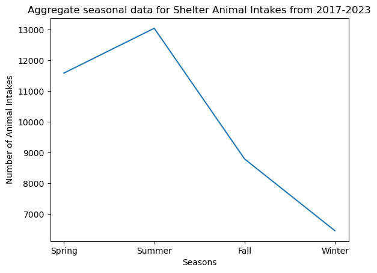

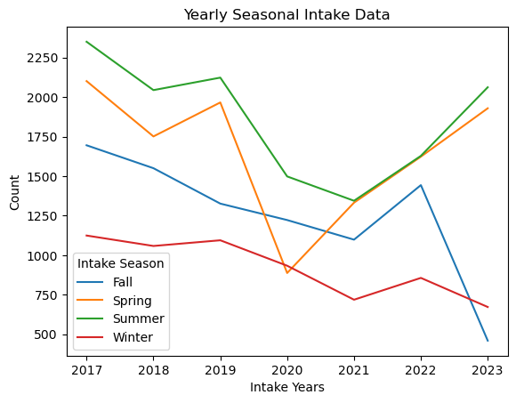

```
Intake Season  Fall  Spring  Summer  Winter
Intake Year
2017           1695    2101    2350    1124
2018           1550    1751    2044    1058
2019           1326    1966    2123    1094
2020           1222     887    1498     933
2021           1098    1332    1344     718
2022           1443    1623    1628     856
2023            459    1929    2062     672
```

```python
#code to ensure there aren't any missing values in the intake date
animal_intake_data = animal_data[animal_data['Intake Date'].notna()]
#print(len(animal_intake_data))

#decided not to use the animal_intake_data since there weren't any missing values
#Code to grab the intake month and add it to another column to compute more easily
animal_data['Intake Month'] = animal_data['Intake Date'].str.slice(start = 5 ,stop = 7)
animal_data.head()

#group months by seasons that I'm separating as: 12-02 winter, 03-05 spring, 06-08 summer, 09-11 fall
#used apply method from: https://pandas.pydata.org/docs/reference/api/pandas.DataFrame.apply.html instead of a for loop
def separating_seasons(month):
    if month in ['12', '01', '02']:
        return 'Winter'
    elif month in ['03', '04', '05']:
        return 'Spring'
    elif month in ['06', '07', '08']:
        return 'Summer'
    elif month in ['09', '10', '11']:
        return 'Fall'

animal_data['Intake Season'] = animal_data['Intake Month'].apply(separating_seasons)

#code to set season order
season_order = ['Spring', 'Summer', 'Fall', 'Winter']

#code to group data by seasons and easily count the intakes
#used this documentation to change the order of the season info: https://pandas.pydata.org/docs/reference/api/pandas.DataFrame.reindex.html
intake_seasonal_counts = animal_data['Intake Season'].value_counts().reindex(season_order)

sns.lineplot(x = intake_seasonal_counts.index, y = intake_seasonal_counts).set(xlabel = 'Seasons', ylabel = 'Number of Animal Intakes', title = 'Aggregate seasonal data for Shelter Animal Intakes from 2017-2023')
plt.show()


#code to separate the seasonal data by year
yearly_seasonal_groups = animal_data.groupby(['Intake Year', 'Intake Season']).size().reset_index(name = 'count')

#setting a pivot table to be able to visualize this
yearly_seasonal_pivot = yearly_seasonal_groups.pivot_table(index = 'Intake Year', columns = 'Intake Season', values = 'count')
#plotting the table
yearly_seasonal_pivot.plot().set(xlabel = 'Intake Years', ylabel = 'Count', title = 'Yearly Seasonal Intake Data')
plt.show()

#printing the tabular representation as well
print(yearly_seasonal_pivot)
```

#### (e) Challenge your results

After completing the exploratory analyses from Problem 2, do you have any concerns about your findings? How well defined was your original question? Do you still believe this question can be answered using this dataset? Comment on any ethical and/or privacy concerns you have with your analysis.

I think the question was well defined because I could measure the values we were looking for; and since it seems there wasn't missing data for the intake dates, I do think this question can still be answered with the dataset. I wish we had information as to whether the intake dates are recorded upon arrival or whether there is any delay in recording this information that might push a given number of intakes from a season to the next. I suppose my concern with the way I mappped the months is it doesn't exactly map the days as well, and this can make a difference since seasons typically start on the 21st of the month.

### Problem 3: Pets returned to owner in Long Beach

For this problem, only consider instances where the jurisdiction is Long Beach and the outcome is that the animal was returned to owner.

#### (a) How many animals?

How many records are there from Long Beach where the animal was returned to owner?

```python
#locating both the jurisdiction and the returned to owner outcome
long_beach_data = animal_data.loc[(animal_data['Jurisdiction'] == 'LONG BEACH') & (animal_data['Outcome Type'] == 'RETURN TO OWNER')]
len(long_beach_data)
```

```
3739
```

There were 3739 instances in which the animal was returned to the owner in long beach.

#### (b) How many types of animals?

How many types of animals are in these records?

```python
#code to locate ALL long beach data, regardless of outcome
all_long_beach_data = animal_data.loc[animal_data['Jurisdiction'] == 'LONG BEACH']
#code to count the specific animal types in long beach
animal_types_long_beach = all_long_beach_data['Animal Type'].value_counts()
print(animal_types_long_beach)
print(len(animal_types_long_beach))
```

```
CAT           16294
DOG           11157
BIRD           2297
OTHER          1626
WILD           1599
RABBIT          548
REPTILE         393
GUINEA PIG      194
LIVESTOCK        10
AMPHIBIAN         3
Name: Animal Type, dtype: int64
10
```

It seems there is quite a diverse group of animals that have been taken to the long beach shelters, in fact all 10 types observed across all data are also found in this jurisdiction.

#### (c) Which types of animals?

Which types of animals are present in the entire data set that are not present when looking at instances where the jurisdiction is Long Beach and the outcome is that the animal was returned to owner?

```python
#finding the animal types for the long beach intakes that were returned to the owner using the code from question a
long_beach_owner_animal_types = long_beach_data['Animal Type'].value_counts()
print(len(long_beach_owner_animal_types))
print(long_beach_owner_animal_types)
```

```
8
DOG           3319
CAT            380
REPTILE         15
BIRD            14
RABBIT           7
GUINEA PIG       2
OTHER            1
WILD             1
Name: Animal Type, dtype: int64
```

When we filter the data down to only outcomes where the animals were returned to their owner we can see only 8 types of animals had this resolution. Only Livestock and Amphibians seem to be the types of animals that don't get returned to their owners.

#### (d) How many of each type of animals?

How many unique animals (not records) are there for each animal from Long Beach where the animal was returned to owner?

```python
#code to filter out the duplicate values based on the animals' names to find the number of unique animals
long_beach_duplicates = long_beach_data[long_beach_data.duplicated(subset = 'Animal ID', keep='first')]
len(long_beach_duplicates)
```

```
338
```

#### (e) Decreases during COVID

Did all animal types see a decrease in intakes during 2020 compared to their pre-2020 annual average? Which animal types saw the largest numerical drop and the largest percent drop?

```python
#filtering for the 2020 intakes
intakes_2020 = animal_data.loc[animal_data['Intake Year'] == '2020']
#filtering for pre-2020 intakes
intakes_pre2020 = animal_data.loc[animal_data['Intake Year'] < '2020']

#finding the overall number of intakes
print(len(intakes_2020))
print(len(intakes_pre2020))

#finding average for pre-pandemic intakes
print(int(len(intakes_pre2020))/3)

#separating the intakes2020 by animal type
animal_intakes_2020 = intakes_2020.groupby('Animal Type').size().reset_index(name = 'Intakes in 2020')

#separating the intakes_pre2020 by animal type and intake year, calculating the number of animals of specific species and adding it to a new 'intakes pre-2020' column
animal_intakes_count_pre2020 = intakes_pre2020.groupby(['Animal Type', 'Intake Year']).size().reset_index(name = 'Intakes pre-2020')

#using the code above, grouping once again but just by species, calculating the mean of the new column made above, resetting index and adding a new column with the mean values
intake_groups_mean = animal_intakes_count_pre2020.groupby('Animal Type')['Intakes pre-2020'].mean().reset_index(name = 'Average pre2020 Intakes')
print(intake_groups_mean)
print(animal_intakes_2020)

#merging the two data frames for intakes in 2020 and pre2020, if there are na values, making them 0
animal_intakes_merge = pd.merge(intake_groups_mean, animal_intakes_2020, on = 'Animal Type', how = 'outer').fillna(0)
#adding a new column to store the numerical difference calculation
animal_intakes_merge['Numerical Difference'] = animal_intakes_merge['Intakes in 2020'] -  animal_intakes_merge['Average pre2020 Intakes']
#adding new column for the % difference, and calculation
animal_intakes_merge['Percent Difference'] = (animal_intakes_merge['Numerical Difference']*100) / (animal_intakes_merge['Average pre2020 Intakes'])

animal_intakes_merge
```

```
4540
20182
6727.333333333333
  Animal Type  Average pre2020 Intakes
0   AMPHIBIAN                 1.000000
1        BIRD               459.000000
2         CAT              3212.333333
3         DOG              2285.333333
4  GUINEA PIG                27.000000
5   LIVESTOCK                 2.000000
6       OTHER               271.666667
7      RABBIT               103.000000
8     REPTILE                88.666667
9        WILD               278.000000
  Animal Type  Intakes in 2020
0        BIRD              397
1         CAT             2224
2         DOG             1254
3  GUINEA PIG               30
4   LIVESTOCK                1
5       OTHER              302
6      RABBIT               58
7     REPTILE               35
8        WILD              239
```

|  | Animal Type | Average pre2020 Intakes | Intakes in 2020 | Numerical Difference | Percent Difference |
| --- | --- | --- | --- | --- | --- |
| 0 | AMPHIBIAN | 1.000000 | 0.0 | -1.000000 | -100.000000 |
| 1 | BIRD | 459.000000 | 397.0 | -62.000000 | -13.507625 |
| 2 | CAT | 3212.333333 | 2224.0 | -988.333333 | -30.766836 |
| 3 | DOG | 2285.333333 | 1254.0 | -1031.333333 | -45.128355 |
| 4 | GUINEA PIG | 27.000000 | 30.0 | 3.000000 | 11.111111 |
| 5 | LIVESTOCK | 2.000000 | 1.0 | -1.000000 | -50.000000 |
| 6 | OTHER | 271.666667 | 302.0 | 30.333333 | 11.165644 |
| 7 | RABBIT | 103.000000 | 58.0 | -45.000000 | -43.689320 |
| 8 | REPTILE | 88.666667 | 35.0 | -53.666667 | -60.526316 |
| 9 | WILD | 278.000000 | 239.0 | -39.000000 | -14.028777 |

There was a significant decrease in animal intakes in 2020 compared to the years prior. From the average across the years 2017-2019, there were 2,200 less intakes in 2020 compared to those 3 years.

Which animal types saw the largest numerical drop and the largest percent drop? Based on the calculations above, the 2 animal types with the largest numerical drop are: dogs, and cats. Compared to the other animal types, their difference in intakes is significant. However, based on percent difference, amphibians are the only animal type with a percent decrease of 100%, and this measure alone would be misleading since there was a mean of 1 intake in the years before 2020 and then none in 2020 itself, which leads to such a huge % difference number.

#### (f) Reflect and Question

What are your thoughts on the questions (and answers) for problem 3? Were you able to answer all of these questions? Are all questions well-defined? Is the data good enough to answer all these?

I struggled with interpreting question D. I think it's pretty arbitrary choosing what unique means, this could be related to Animal ID's or Names. I chose the animal ID parameter as that would be truly unique to each animal, but I can't be 100% sure. I think this was the only question that made me scratch my head and wonder about the data's provenance. I enjoyed the set of questions in part E, though it took me a rather long time to figure out how to compute it, but I liked that the questions asked for both numerical differences and percent differences as one without the other could be misleading as I pointed out in my answer above.